# Devoir 2

Votre noms d’équipe

13/03/2024

# À remettre sur Moodle au plus tard le 27 mars 2024 avant le début du cours.

## Question 1

### Mise en contexte

Vous êtes impliqué dans un projet dont l’intérêt est d’étudier comment deux espèces bactériennes interagissent entre elles dans un environnement hautement contrôlé (c’est-à-dire une boîte de Petri). Au début de l’expérience, 25 individus de l’espèce *bogustonia proii* et 20 individus de l’espèce *aleastonia predatora* ont été inoculés dans la boîte de Petri. Pendant l’expérience, les individus de chaque espèce ont été comptés indépendamment toutes les heures pendant deux semaines (beaucoup d’efforts et de nuits blanches ont été nécessaires pour ce projet).

Les données qui ont été recueillies pendant ces deux semaines sont disponibles dans le fichier `2Bacteries.csv`.

Un chercheur impliqué dans le projet pense que la relation entre les deux espèces bactériennes est une relation consommateur-ressource, mais il n’est pas certain de comment construire un modèle pour tester cette hypothèse. Comme il y a plusieurs façons de construire un modèle consommateur-ressource, proposer un modèle consommateur-ressource qui vous permettra de mieux caractériser la dynamique entre les deux espèces.

*Indice :* Un des chercheurs de l’équipe qui connait très bien l’espèce *bogustonia proii* a remarqué que dans une expérience similaire qui n’a durée que 5 jours, le taux de croissance de cette espèce n’était pas constant. Plus il y avait d’individu moins le taux de croissance était élevé.

### 2 points

1. Présenter le modèle que vous souhaitez utiliser. Assurez-vous de bien définir la notation pour le modèle.

#### Modèle Lotka-Volterra entre l’espèce *bogustonia proii* et l’espèce *aleastonia predatora*

##### $\frac{dR}{dt} = \alpha R(t) (1 - \frac{R(t)}{K}) - \beta R(t)C(t)$

##### $\frac{dC}{dt} = \epsilon \beta R(t)C(t) - \delta C(t)$

$R(t)$ : Taille de la population de *bogustonia proii*  
$C(t)$ : Taille de la population de *aleastonia predatora*  
$\alpha$ : Taux de croissance de *bogustonia proii*  
$K$ : Capacité maximale de support de l’environnement à *bogustonia proii*  
$\beta$ : Coefficient de la force de l’interaction entre les populations  
$\epsilon$ : Taux de transformation de la consommation d’une ressource en nouveau consommateur $\delta$ : Taux de mortalité de *aleastonia predatora*

### 8 points

2. Implémentez le modèle que vous considérez le plus approprié dans R en utilisant les techniques apprises en cours et essayez une série de valeurs différentes pour trouver les meilleures paramètres. Utilisez la corrélation de Pearson pour trouver les paramètres qui correspondent le mieux aux données.

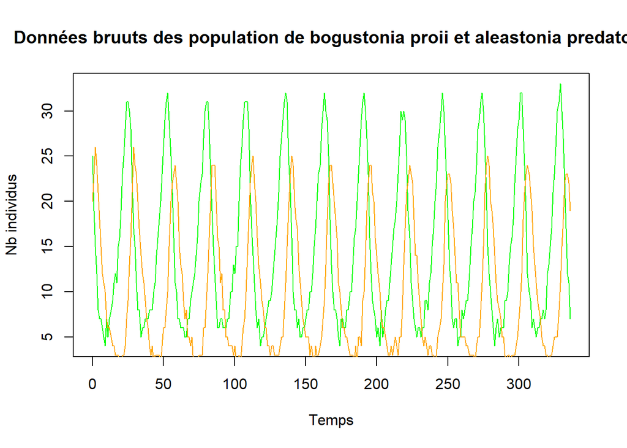

```r
#librairie
library(deSolve)

# lecture des données
bact <- read.csv("2Bactéries.csv")

# Créer un nouveau graphique avec la ligne bogustonia proii
plot(x = bact$temps, y = bact$bogustonia_proii, type = "l", col = "green",
     xlab = "Temps", ylab = "Nb individus", main = "Données bruuts des population de bogustonia proii et aleastonia predatora")

# Ajouter la ligne aleastonia predatora
lines(x = bact$temps, y = bact$aleastonia_predatora, col = "orange")
```

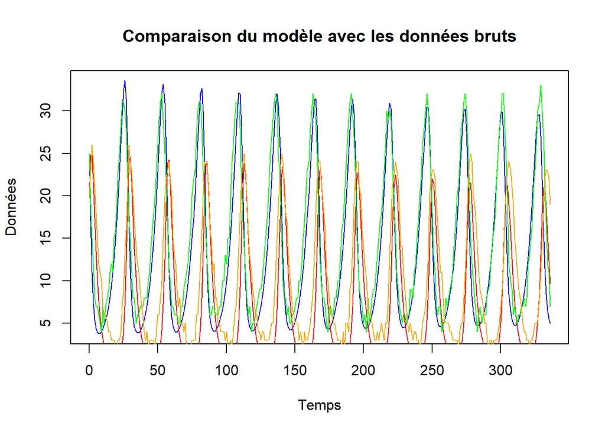

```
## [1] "alpha = 0.17 beta = 0.0242 epsilon = 1.21 delta = 0.401"
## [1] "Ressource : 0.9637"
## [1] "Consomateur : 0.9578"
```

```r
# Fonction du modele consommateur ressource
C_RVector <- function(t, vars, parms){
  with(as.list(c(parms, vars)), {
    # Modèle consommateur ressoure
    dR <- alpha*R*(1-R/2000) - beta*R*C # dR/dt
    dC <- (epsilon*beta)*R*C - delta*C  # dC/dt

    # Résultat
    res <- c(dR=dR, dC=dC)
    return(list(res))
  })
}

# Fonction pour dessiner la solution
dessinSol <- function(ic=c(R=25,C=20), times=bact$temps,func=C_RVector, parms=c(alpha=0.4,beta=0.2,epsilon=1,delta=0.91)) {

  # Applique le modele avec les parammetres
  soln <- ode(ic, times, func, parms)

  # Trouve les correlations avec du modele
  correlation_R <- cor(bact$bogustonia_proii, soln[,"R"])
  correlation_C <- cor(bact$aleastonia_predatora, soln[,"C"])

  # Créer un nouveau graphique avec la ligne du modele bogustonia proii
  plot(x = times, y = soln[,"R"], type = "l", col = "blue",
       xlab = "Temps", ylab = "Données",
       main = "Comparaison du modèle avec les données bruts")

  # Ajouter la ligne du modele aleastonia predatora
  lines(x = times, y = soln[,"C"], col = "red")
  # Ajouter la ligne brute bogustonia proii
  lines(x = bact$temps, y = bact$bogustonia_proii, col = "green")
  # Ajouter la ligne brute aleastonia predatora
  lines(x = bact$temps, y = bact$aleastonia_predatora, col = "orange")

  # presentation de parammetre et correlation
  print(paste("alpha =", parms[1],"beta =", parms[2],"epsilon =", parms[3],"delta =", parms[4]))
  print(paste("Ressource :",round(correlation_R,4)))
  print(paste("Consomateur :",round(correlation_C,4)))
}

# best resultat
dessinSol(parms = c(alpha=0.17,beta=0.0242,epsilon=1.21,delta=0.401),func = C_RVector)
```

### 1 point

3. Même si vous n’obtenez pas un modèle qui s’adapte très bien aux données, expliquez brièvement comment vous pensez que les différents modèles que vous obtenez peuvent aider à rejeter (ou non) l’hypothèse proposée par ce chercheur.

### 1 point

4. Après avoir étudié les données en utilisant le modèle ressource-consommateur à la question précédent, proposez une nouvelle expérience qui aiderait à donner des réponses plus précises sur les facteurs générant le comportement périodique trouvé pour les deux espèces bactériennes.

Assurez-vous que l’expérience puisse être réalisée dans un délai raisonnable (au maximum 2 semaines).

Il serait intéressant de refaire la même expérience, mais de varier le nombre de départ de ressource avec un grand nombre ou le nombre de consommateurs pour voir si le comportement périodique est affecté. Cela permettrait de confirmer le portrait de phase lié au modèle.

## Question 2 (10 points)

Considerons le modèle de métapopulation de Levins,
$$\begin{align}
\frac{dP}{dt} = cN_{occ}\left(1-\frac{N_{occ}}{N}\right)- eN_{occ}, \,
\qquad N_{occ}(0)=N_{ini},
\end{align}$$
où $c$ est le taux de colonisation, $e$ le taux d’extinction, $N$ le nombre de sites considérés et $N_{occ}$ le nombre de sites où l’espèce est présente et $N_{occ}(t)$ est la nombre de sites occupés au temps $t$.

Écrivez la fonction `R` `metapopGill()` qui implémente l’algorithme de Gillespie pour produire une réalisation du processus stochastique pour le modèle de métapopulation de Levins tel que définit par l’équation ci-dessus lorsque $N_{occ} \to \left(1-\frac{e}{c}\right)N$. Votre fonction doit avoir les arguments `col`, `ext`, `N`, `Nini` (nombre initial de site où l’espèce est présente) et `tmax` (le temps après lequel la simulation se termine).

Indice : il faut utiliser une boucle `while`.

Note : N’oubliez pas de commenter votre code.

```
## [1] 11961
```

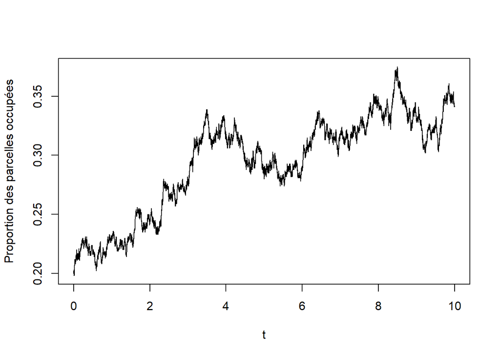

```
## [1] "la fonction tend vers 337 parcelles occupées, l'équilibre théorique est à   333 parcelles occupées"
```

```r
metapopGill <- function (col, ext, N, Nini, tmax){

  #on définit l'équilibre théorique
  theo <- (1- ext/col)*N

  #On définit le nombre de parcelles colonisées
  Nocc <- Nini

  #On définit le nombre de parcelles non-occupées
  Nabs <- N - Nini

  #on amorce
  tendance <- -1
  t <- 0
  tevol <- 0
  Nevol <- Nini
  while (t<tmax & Nocc>0){

    #on définit le vecteur avec les taux d'évènements
    a <- c(col*Nocc*(1-(Nocc/N)), ext*Nocc)
    #a <- c(col,ext)

    #on définit le taux global d'évènement
    a0 <- sum(a)

    #on définit u stochastiquement
    u <- runif(1)

    #on calcule le temps t au prochain évènement
    te <- 1/a0 *log(1/u)
    t <- t+te

    #on détermine stochastiquement quels évènement se produira
    e <- runif(1,0,a0)

    if (e<a[1]){
      Nocc <- Nocc+1
      Nabs <- Nabs-1
    } else {
      Nabs <- Nabs+1
      Nocc <- Nocc-1
    }
    #on fabrique la série temporelle
    Nevol <- c(Nevol,Nocc)
    tevol <- c(tevol,t)

  }
  if(Nocc!=0){
    #Pour calculer l'équilibre simulé à partir du dernier quartile de temps
    pas <- length(Nevol)
    fin <- round(pas*0.25,0)
    tendance <- round(mean(tail(Nevol,fin)))

    #imprime le nombre d'étapes effectuées
    print(length(tevol))

    #on affiche une courbe de la simulation
    plot(tevol,Nevol/N,type = "l",
         xlab="t",
         ylab="Proportion des parcelles occupées")
    res<-paste(c("la fonction tend vers ",tendance," parcelles occupées, l'équilibre théorique est à   ",round(theo)," parcelles occupées"),collapse = "")
    return(res)
    } else { #dans le cas où la métapopulation s'éteint avant tmax
      #imprime le nombre d'étapes effectuées
      print(length(tevol))

      #on affiche une courbe de la simulation
      plot(tevol,Nevol/N,type = "l",
           xlab="t",
           ylab="Proportion des parcelles occupées")
      res<-paste(c("La métapopulation s'effondre, l'équilibre théorique est à ",round(theo)," parcelles occupées"),collapse = "")
      return(res)
    }
}
#un exemple
metapopGill(3,2,1000,200,10)
```

## Question 3 (10 points)

Comparer 3 itérations du modèle de métapopulation stochastiques avec le modèle de métapopulation déterministique pour $c=2$, $e=1$ $N_{ini}=1$ et $N\in\{100,1000,10000, 100000\}$. Présenter vos résultats dans des graphiques où chaque figure est définit par une valeur différente de $N$.

Quand N est très élevé, la fonction ‘metapopGill()’ prend beaucoup de temps

```
## [1] 1244
```

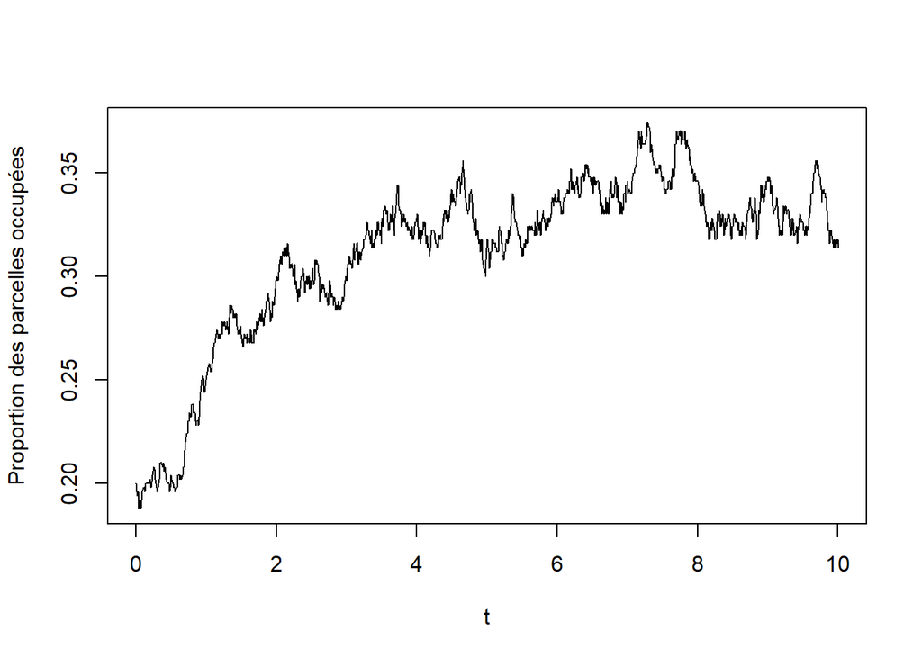

```
## [1] "la fonction tend vers 335 parcelles occupées, l'équilibre théorique est à 333 parcelles occupées"
```

```r
metapopGill2 <- function (col, ext, N, Nini, tmax){

  #on définit l'équilibre théorique
  theo <- (1- ext/col)*N

  #On définit le nombre de parcelles colonisées
  Nocc <- Nini

  #On définit le nombre de parcelles non-occupées
  Nabs <- N - Nini

  #On amorce les objets suivant pour la boucle et la simulation
  tendance <- -1
  t <- 0
  tevol <- 0
  Nevol <- Nini
  #boucle tournant pour toute la simulation
  while (t<=tmax & Nocc>0){

    #on définit le vecteur avec les taux d'évènements
    a <- c(col*Nocc*(1-(Nocc/N)), ext*Nocc)
    #a <- c(col,ext)

    #on définit le taux global d'évènement
    a0 <- sum(a)

    #on réinitialise les colonisations et extinctions
    tt <- 0
    cols <- 0
    exts <- 0
    for(i in 1:10){
      #on définit u stochastiquement
      u <- runif(1)

      #on calcule le temps t au prochain évènement
      te <- 1/a0 *log(1/u)
      tt <- tt+te

      #on détermine stochastiquement quels évènement se produira
      e <- runif(1,0,a0)

      if (e<a[1]){
        cols <- cols + 1
      } else {
        exts <- exts + 1
      }
    }
    #on met à jour Nocc et on poursuit la série temporelle
    Nocc <- Nocc + cols - exts
    t <- t+tt
    Nevol <- c(Nevol,Nocc)
    tevol <- c(tevol,t)
  }
  #output quand la simulation arrive à tmax
  if(Nocc>0){
    #on calcule l'équlibre à partir du dernier quartile de temps
    pas <- length(Nevol)
    fin <- round(pas*0.25,0)
    tendance <- round(mean(tail(Nevol,fin)))
    #le nombre d'étapes effectuées
    print(length(tevol))
    #on affiche une courbe de la simulation
    plot(tevol,Nevol/N,type = "l",
         xlab="t",
         ylab="Proportion des parcelles occupées")
    res<-paste(c("la fonction tend vers ",tendance," parcelles occupées, l'équilibre théorique est à ",round(theo)," parcelles occupées"),
               collapse = "")
    return(res)
  } else {
    #output si la population crash avant tmax
    #le nombre d'étapes effectuées avant le crash
    print(length(tevol))
    #on affiche une courbe de la simulation
    plot(tevol,Nevol/N,type = "l",
         xlab="t",
         ylab="Proportion des parcelles occupées")
    res<-paste(c("La métapopulation s'effondre, l'équilibre théorique est à ",round(theo)," parcelles occupées"),
               collapse = "")
    return(res)
  }
}
#un exemple
metapopGill2(3,2,1000,200,10)
```

### Résultat pour $N=100$

```r
set.seed(102)
metapopGill(2,1,100,1,20)
```

```
## [1] 1839
```

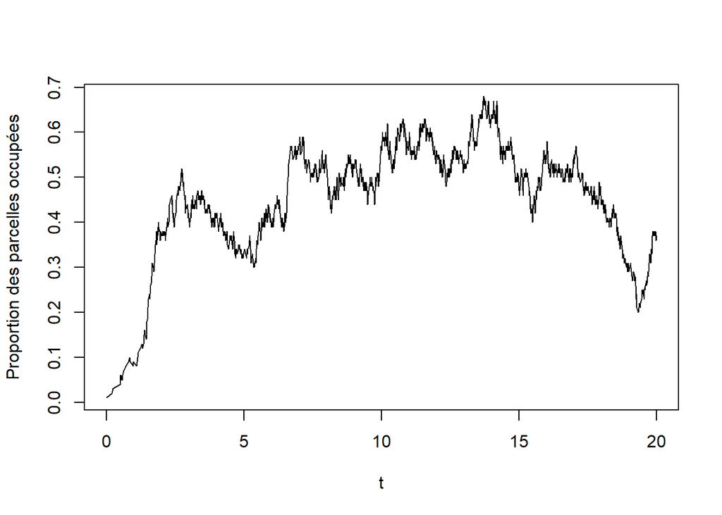

```
## [1] "la fonction tend vers 44 parcelles occupées, l'équilibre théorique est à   50 parcelles occupées"
```

### Résultat pour $N=1000$

```r
set.seed(102)
metapopGill(2,1,1000,1,20)
```

```
## [1] 16239
```

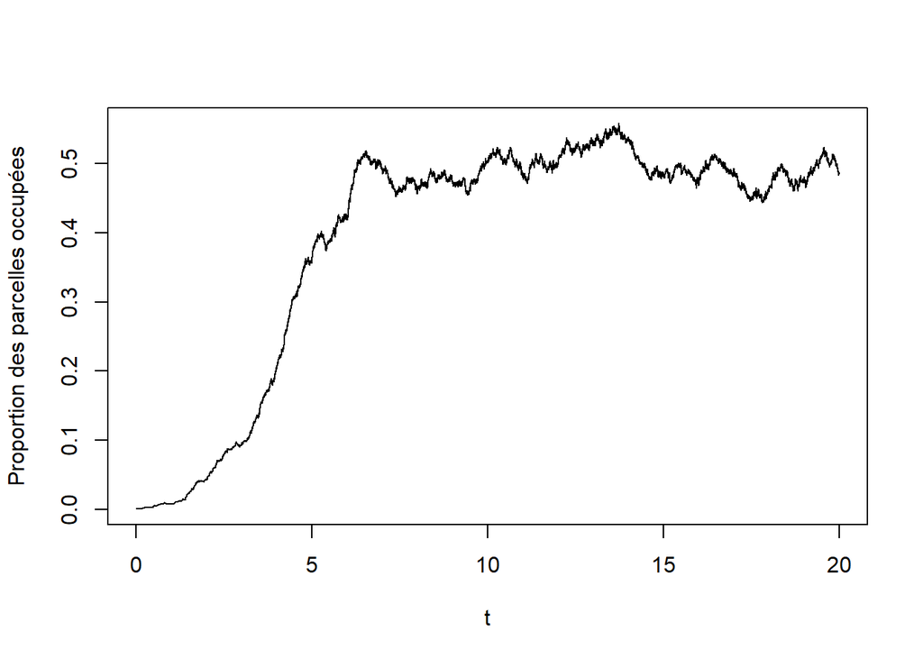

```
## [1] "la fonction tend vers 483 parcelles occupées, l'équilibre théorique est à   500 parcelles occupées"
```

### Résultat pour $N=10000$

```r
set.seed(102)
metapopGill(2,1,10000,1,20)
```

```
## [1] 141963
```

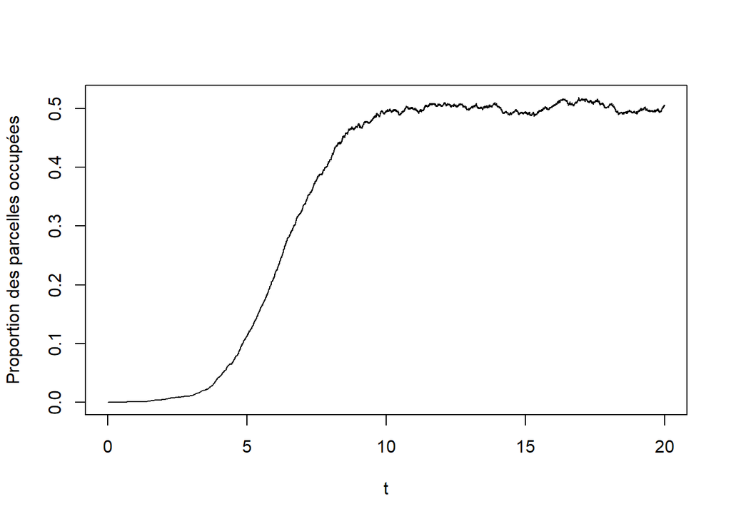

```
## [1] "la fonction tend vers 5027 parcelles occupées, l'équilibre théorique est à   5000 parcelles occupées"
```

### Résultat pour $N=100000$

```r
set.seed(102)
metapopGill2(2,1,100000,1,20)
```

```
## [1] 104316
```

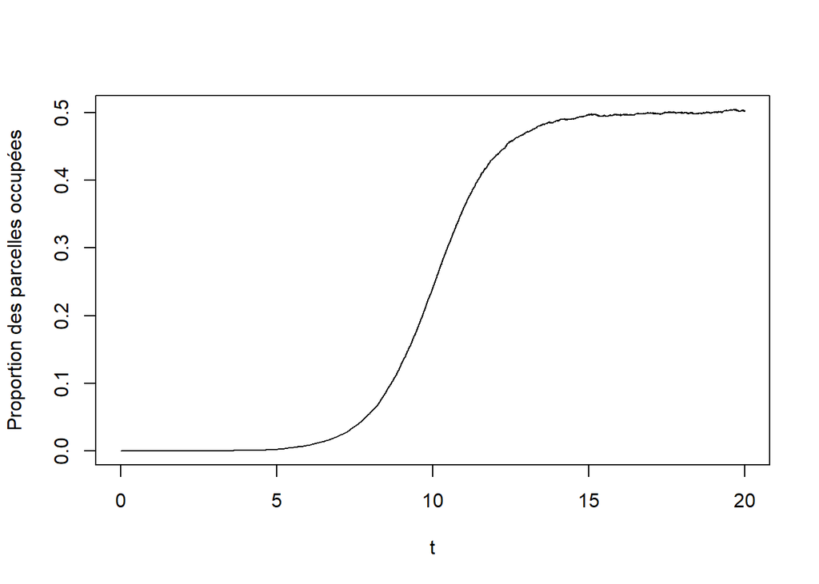

```
## [1] "la fonction tend vers 50082 parcelles occupées, l'équilibre théorique est à 50000 parcelles occupées"
```

## Question 4 (2 points)

Expliquer brièvement comment la taille de la population totale ($N$) influence la dynamique stochastique du modèle de métapopulation.

Il semble que l’augmentation du nombre de patch ($N$) sans changer le nombre de parcelles intialement colonisées allonge la durée de la période de transition, en plus d’aplatir la courbe en début de simulation. L’équilibre est le même, mais prend plus de temps à atteindre